# Compare the Estimations of Logit and Conditional Logit

Wei-Lun, Lin

2026-04-29

## 1. Setting of the Conjoint Experiment

**The Choice Task** In our experimental setting, we employ a forced-choice, paired-comparison design. A subject is presented with a sequence of independent trials (choice sets). In each trial, the subject evaluates exactly two mutually exclusive alternatives and is forced to choose their preferred option.

**Attributes and Profiles** Each alternative is defined by a specific combination of $L$ attributes. To facilitate modeling, these categorical attributes are converted into dummy variables, resulting in a total of $P$ parameters. Thus, any given alternative can be mathematically represented as a $1 \times P$ feature vector $X$. To prevent perfectly predictable choices, the experimental design ensures that the two alternatives within a single trial are never perfectly identical.

**Random Utility Theory (RUM)** The statistical modeling of the conjoint experiment is grounded in the Random Utility Model (RUM). RUM assumes that decision-makers act rationally to maximize their utility. The total latent utility $U$ that a subject derives from an alternative is assumed to consist of two additive components: 1. Deterministic Utility ($V$): The observable portion of utility, modeled as a linear combination of the alternative’s attributes and the subject’s underlying preferences (part-worth utilities), such that $V = X\boldsymbol\beta$. 2. Stochastic Utility ($\epsilon$): An unobservable, random error term capturing idiosyncratic preferences, unmeasured attributes, or decision noise.

Under this framework, a subject will choose Alternative 1 over Alternative 2 if and only if $U_1 > U_2$. The goal of the Maximum Likelihood Estimation (MLE) is to recover the true preference parameters ($\beta$) based on the observed choices. Depending on how the probabilistic structure of the choice set is defined, researchers typically employ either standard Logistic Regression or the Conditional Logit model.

## 2. Mathematical Notations

Throughout the MLE derivation for the two models, we will use the following indices and variables:

- **Indices**:
  - $i \in \{1, \dots, n\}$: Subject.
  - $j \in \{1, 2\}$: Alternative.
  - $k \in \{1, \dots, K\}$: Choice task (trial).
  - The total number of observations (rows of data in long format) is $2 \times n \times K$.
- **Variables**:
  - $y_{ijk} \in \{0, 1\}$: The dependent variable. It equals $1$ if subject $i$ chooses alternative $j$ in task $k$, and $0$ otherwise. Within a single task, the forced-choice condition ensures $y_{i1k} + y_{i2k} = 1$.
  - $X_{ijk}$: A $1 \times P$ feature vector representing the attribute profile of alternative $j$.
  - $\boldsymbol{\beta}$: A $P \times 1$ vector of parameters to be estimated.
  - $\beta_0$: The intercept term, specific to the logistic regression model.

## 3. Models

We compare two models: logistic regression and conditional logit model.

### 3.1. Logistic Regression

The core assumption of standard Logistic Regression is that **each row of data (each alternative) is treated as an independent Bernoulli trial**. It completely ignores the mutually exclusive and competitive relationship between Alternative 1 and Alternative 2 within the same trial.

#### Step 3.1.1: Define the Probability Function

The probability $\pi_{ijk}$ that an alternative is selected is the inverse-logit transformation of its absolute utility plus the intercept:
$$P(y_{ijk}=1) = \pi_{ijk} = \frac{\exp(\beta_0 +
X_{ijk}\boldsymbol\beta_{LR})}{1 + \exp(\beta_0 +
X_{ijk}\boldsymbol\beta_{LR})}$$

#### Step 3.1.2: Likelihood Function

The likelihood function $\mathcal{L}_{LR}$ is the product of the probabilities of all $2nK$ independent events occurring:
$$\mathcal{L}(\beta_0, \boldsymbol\beta_{LR}) =
\prod_{i=1}^{n} \prod_{j=1}^{2} \prod_{k=1}^{K} (\pi_{ijk})^{y_{ijk}} (1
- \pi_{ijk})^{1 - y_{ijk}},$$

and the log-likelihood is:
$$\begin{align*}
\ell(\beta_0, \boldsymbol\beta_{LR})
&= \sum_{i=1}^{n} \sum_{j=1}^{2} \sum_{k=1}^{K} \left[
y_{ijk} \ln(\pi_{ijk}) + (1 - y_{ijk}) \ln(1 - \pi_{ijk})
\right] \\
&= \sum_{i=1}^{n} \sum_{j=1}^{2} \sum_{k=1}^{K} \left\{
y_{ijk} \ln[\frac{\exp(\beta_0 + X_{ijk}\boldsymbol\beta_{LR})}{1
+ \exp(\beta_0 + X_{ijk}\boldsymbol\beta_{LR})}] +
(1-y_{ijk}) \ln[{1\over 1 + \exp(\beta_0 +
X_{ijk}\boldsymbol\beta_{LR})}]
\right\}
\\
&= \sum_{i=1}^{n} \sum_{j=1}^{2} \sum_{k=1}^{K} \left[ y_{ijk}
(\beta_0 + X_{ijk}\boldsymbol\beta_{LR}) - \ln(1 + \exp(\beta_0 +
X_{ijk}\boldsymbol\beta_{LR})) \right].
\end{align*}$$

#### Step 3.1.3: Derive the First Order Derivative

To find the maximum, we take the partial derivative with respect to the parameters $\boldsymbol\beta_{LR}$ and $\beta_0$ and set them to 0:

$$\begin{cases}
&\frac{\partial \ell_{LR}}{\partial \boldsymbol\beta_{LR}}
= \sum_{i,k,j} \left[
y_{ijk} X_{ijk}
- \frac{\exp(\beta_0 + X_{ijk}\boldsymbol\beta_{LR})}{1 +
\exp(\beta_0 + X_{ijk}\boldsymbol\beta_{LR})} X_{ijk}
\right]
&= \sum_{i,k,j} (y_{ijk} - \pi_{ijk}) X_{ijk}, \\
&\frac{\partial \ell_{LR}}{\partial \beta_0}
= \sum_{i,k,j} \left[
y_{ijk}
- \frac{\exp(\beta_0 + X_{ijk}\boldsymbol\beta_{LR})}{1 +
\exp(\beta_0 + X_{ijk}\boldsymbol\beta_{LR})}
\right]
&= \sum_{i,k,j} (y_{ijk} - \pi_{ijk}).
\end{cases}$$

### 3.2. Conditional Logit

The core assumption of the Conditional Logit model (McFadden’s Choice Model) is that **choice behavior occurs strictly within the boundaries of the Choice Set**. The probability is founded on the relative comparison between the alternatives competing within the same trial.

#### Step 3.2.1: Define the Probability Function

Based on the Random Utility Model, assuming the error terms $\epsilon$ follow an i.i.d. Type I Extreme Value distribution, the probability $P_{ijk}$ that a subject chooses alternative $j$ in task $k$ depends entirely on its relative utility within the set:
$$P(y_{ijk}=1 |
\text{Choice Set } ik) = P_{ijk} =
\frac{\exp(X_{ijk}\boldsymbol\beta_{CL})}{\sum_{m=1}^{2}
\exp(X_{imk}\boldsymbol\beta_{CL})}$$

#### Step 3.2.2: Likelihood Function

Within the same trial, the probabilities of the two alternatives sum to $1$, and the subject must choose exactly one ($\sum_j y_{ijk} = 1$). Consequently, the probability contributed by the entire trial is simply the “probability of the chosen alternative.” The likelihood function $\mathcal{L}_{CL}$ is the joint probability across all $n \times K$ choice sets:
$$\mathcal{L}(\boldsymbol\beta_{CL}) =
\prod_{i=1}^{n} \prod_{j=1}^{2} \prod_{k=1}^{K}
(P_{ijk})^{y_{ijk}}$$

, and the log-likelihood is:
$$\begin{align*}
\ell(\boldsymbol\beta_{CL})
&= \sum_{i=1}^{n} \sum_{j=1}^{2} \sum_{k=1}^{K} y_{ijk}
\ln(P_{ijk}) \\
&= \sum_{i=1}^{n} \sum_{j=1}^{2} \sum_{k=1}^{K} y_{ijk}
\ln\left[
\frac{\exp(X_{ijk}\boldsymbol\beta_{CL})}{\sum_{m=1}^{2}
\exp(X_{imk}\boldsymbol\beta_{CL})}
\right] \\
&= \sum_{i=1}^{n} \sum_{j=1}^{2} \sum_{k=1}^{K} y_{ijk} \left\{
X_{ijk}\boldsymbol\beta_{CL} - \ln\left[
\sum_{m=1}^{2} \exp(X_{imk}\boldsymbol\beta_{CL})\right]
\right\}.
\end{align*}$$

#### Step 3.2.3: Derive the First Order Derivative

Take the partial derivative with respect to the parameter $\boldsymbol\beta_{CL}$:
$$\begin{align*}
\frac{\partial \ell(\boldsymbol\beta_{CL})}{\partial
\boldsymbol\beta_{CL}}
&= \sum_{i=1}^{n} \sum_{j=1}^{2} \sum_{k=1}^{K} \left[ y_{ijk}
X_{ijk} - \frac{\exp(X_{ijk}\boldsymbol\beta_{CL}) X_{ijk}}{\sum_{m=1}^2
\exp(X_{imk}\boldsymbol\beta_{CL})} \right] \\
&= \sum_{i=1}^{n} \sum_{j=1}^{2} \sum_{k=1}^{K}(y_{ijk} -
P_{ijk})X_{ijk}.
\end{align*}$$

### 3.3. Comparison Between Logistic Regression and Conditional Logit

As derivation above, the log-likelihood function of logistic regression is:
$$\ell(\beta_0,
\boldsymbol\beta_{LR}) = \sum_{i=1}^{n} \sum_{j=1}^{2} \sum_{k=1}^{K}
\left[ y_{ijk} (\beta_0 + X_{ijk}\boldsymbol\beta_{LR}) - \ln(1 +
\exp(\beta_0 + X_{ijk}\boldsymbol\beta_{LR})) \right],$$
and that of conditional logit is:
$$\ell(\boldsymbol\beta_{CL}) =
\sum_{i=1}^{n} \sum_{j=1}^{2} \sum_{k=1}^{K} y_{ijk} \left\{
X_{ijk}\boldsymbol\beta_{CL} -
\ln\left[\sum_{m=1}^{2} \exp(X_{imk}\boldsymbol\beta_{CL})\right]
\right\}$$

## 4. Simulation

### 4.1. Conjoint Experiment Design Setup

The simulation employs a forced-choice, paired-comparison conjoint experiment framework.

- **Choice Sets:** Each choice task consists of exactly two mutually exclusive alternatives (Alternative A and Alternative B).
- **Attributes and Levels:** The number of attributes, denoted as $L$, is manipulated systematically as an experimental condition (e.g., $L \in \{1, 2, 3, 5, 8, 9, 10, 11\}$). Every attribute is binary, possessing exactly two levels (coded as 0 and 1).
- **Orthogonality and Distinctiveness:** The choice sets are derived from a full factorial design space ($2^L$ possible profiles) with two strict constraints applied to the pairs:
  1. **No Ties:** The two alternatives within a single choice set are strictly distinct. Pairs with identical profiles across all attributes are excluded.
  2. **No Repetitions:** Each paired combination is unique. Profiles like (profile $i$ vs profile $j$) and (profile $j$ vs profile $i$) are treated as the same underlying choice set.
- **Position Bias Control:** The left-right (or top-bottom) placement of the two alternatives within a trial is completely randomized with a 50% probability to ensure the baseline choice probability remains perfectly symmetric at 0.5 (yielding a theoretical intercept of 0).

### 4.2. Data Generating Process (Simulation Setup)

The synthetic data is generated based on the Random Utility Model (RUM) framework. To ensure robustness, the simulation utilizes a Monte Carlo approach with multiple random draws for the true parameters.

$$\beta \sim \mathcal{N}(0, 1) \quad \text{bounded by } [-2.5, 2.5]$$

To marginalize out specific parameter-draw biases, multiple independent sets of $\beta$ are drawn for each experimental condition. * **Decision Rule:** The total utility $U$ of alternative $j$ for subject $i$ in trial $k$ is formulated as:

$$U_{ijk} = X_{ijk}\boldsymbol{\beta} + \epsilon_{ijk},$$

where $X_{ijk}$ is the row vector of attribute levels, and $\epsilon_{ijk}$ is the pure random error term drawn from an independent and identically distributed (i.i.d.) Type I Extreme Value (Gumbel) distribution. The subject strictly chooses the alternative that yields the highest total utility (i.e., $Y_{ij^*k} = 1$ if $U_{ij^*k} > U_{ijk}$, and $0$ otherwise).

```r
#' 向量化且極速的 Conjoint 模擬 (嚴格正交無平局設計)
run_orthogonal_conjoint_sim <- function(n_sims = 100, n_subj = 300, n_trials = 10, n_attr = 1, true_beta = c(1.5)) {

  # 1. 預先建立選項庫與配對庫
  profiles <- as.matrix(expand.grid(replicate(n_attr, c(0, 1), simplify = FALSE)))
  colnames(profiles) <- paste0("X", 1:n_attr)
  n_profiles <- nrow(profiles)

  valid_pairs <- combn(1:n_profiles, 2)
  max_possible_trials <- ncol(valid_pairs)
  actual_trials <- min(n_trials, max_possible_trials)

  total_obs <- n_subj * actual_trials * 2
  trial_ids <- rep(1:(n_subj * actual_trials), each = 2)

  res_cl <- matrix(NA, nrow = n_sims, ncol = n_attr)
  res_lr <- matrix(NA, nrow = n_sims, ncol = n_attr + 1)

  f_lr <- as.formula(paste("choice ~", paste(colnames(profiles), collapse = " + ")))
  f_cl <- as.formula(paste("choice ~", paste(colnames(profiles), collapse = " + "), "+ strata(trial_id)"))

  for (s in 1:n_sims) {
    # --- 極速向量化資料生成 ---
    # 1. 一次性為所有受試者抽出 actual_trials 個不重複組合
    # replicate 會產生 actual_trials x n_subj 的矩陣，轉為 vector 即可攤平
    sampled_pairs_idx <- as.vector(replicate(n_subj, sample(1:max_possible_trials, actual_trials, replace = FALSE)))

    idx1 <- valid_pairs[1, sampled_pairs_idx]
    idx2 <- valid_pairs[2, sampled_pairs_idx]

    # 2. 隨機對調左右順序避免位置偏誤
    swap <- runif(length(idx1)) > 0.5
    temp <- idx1
    idx1[swap] <- idx2[swap]
    idx2[swap] <- temp[swap]

    # 3. 建立 Design Matrix (X)
    X <- matrix(0, nrow = total_obs, ncol = n_attr)
    X[c(TRUE, FALSE), ] <- profiles[idx1, ] # 偶數列放選項 1
    X[c(FALSE, TRUE), ] <- profiles[idx2, ] # 奇數列放選項 2

    # 4. 矩陣運算計算效用與機率
    V <- X %*% true_beta
    eps <- -log(-log(runif(total_obs)))
    U <- V + eps

    U_mat <- matrix(U, ncol = 2, byrow = TRUE)
    winner <- max.col(U_mat)

    choice <- as.numeric(rep(c(1, 2), times = total_obs/2) == rep(winner, each = 2))

    # 組裝 Dataframe 以供模型配適
    df <- data.frame(trial_id = trial_ids, choice = choice)
    df <- cbind(df, as.data.frame(X))
    colnames(df)[3:(2+n_attr)] <- colnames(profiles)

    # --- 模型配適 ---
    fit_cl <- clogit(f_cl, data = df)
    res_cl[s, ] <- coef(fit_cl)

    suppressWarnings({ fit_lr <- glm(f_lr, family = binomial, data = df) })
    res_lr[s, ] <- coef(fit_lr)
  }

  # 彙整與計算 (Mean, Bias, Variance, MSE)
  mean_cl_raw <- colMeans(res_cl)
  mean_lr_raw <- colMeans(res_lr)

  # LR 的截距項真實值理論上為 0
  true_beta_lr <- c(0, true_beta)

  # 計算 Bias (估計平均值 - 真實值)
  bias_cl_raw <- mean_cl_raw - true_beta
  bias_lr_raw <- mean_lr_raw - true_beta_lr

  # 計算 Variance (跨模擬次數的變異)
  var_cl_raw <- apply(res_cl, 2, var)
  var_lr_raw <- apply(res_lr, 2, var)

  # 計算 MSE (Bias 的平方 + Variance)
  mse_cl_raw <- bias_cl_raw^2 + var_cl_raw
  mse_lr_raw <- bias_lr_raw^2 + var_lr_raw

  # 組合輸出 Dataframe，將 CL 的資料對齊 (截距項補 NA)
  results_df <- data.frame(
    Term         = c("Intercept", colnames(profiles)),
    True_Beta    = true_beta_lr,
    CL_Mean      = c(NA, mean_cl_raw),
    LR_Mean      = mean_lr_raw,
    CL_Bias      = c(NA, bias_cl_raw),
    LR_Bias      = bias_lr_raw,
    CL_Var       = c(NA, var_cl_raw),
    LR_Var       = var_lr_raw,
    CL_MSE       = c(NA, mse_cl_raw),
    LR_MSE       = mse_lr_raw,
    Ratio_LR_CL  = c(NA, mean_lr_raw[-1] / mean_cl_raw)
  )
}
```

```r
if (file.exists("./2-res/0-simulation/simulation.rds")) {
  final_results_df <- read_rds("./2-res/0-simulation/simulation.rds")
} else {
  # 1. 建立更嚴謹的參數網格 (加入 beta_draw_id)
  sim_grid <- expand.grid(
    n_attr = c(1, 2, 3, 5, 8, 9, 10, 11),
    # 在同一個 L 和 Beta_SD 下，我們測試 15 種完全不同的 true_beta 組合
    beta_draw_id = 1:15
  )

  cat("總共測試", nrow(sim_grid), "種情境組合 (包含多組獨立 Beta 抽樣)...\n")
  all_results <- list()

  for (i in 1:nrow(sim_grid)) {
    current_L <- sim_grid$n_attr[i]
    current_draw_id <- sim_grid$beta_draw_id[i]

    if(i %% 20 == 0) cat(sprintf("進度 %d/%d ...\n", i, nrow(sim_grid)))

    # 確保每次抽出的 beta 組合都不同
    set.seed(12345 + i)
    current_true_beta <- rtruncnorm(n = current_L, a = -2.5, b = 2.5, mean = 0, sd = 1)

    # 執行極速模擬 (為了配合多組 beta，n_sims 設為 30 即可維持穩健性與速度平衡)
    res_df <- run_orthogonal_conjoint_sim(
      n_sims = 30,
      n_subj = 300,
      n_trials = 10,
      n_attr = current_L,
      true_beta = current_true_beta
    )

    # 標記這是哪一組 beta 的結果
    res_df <- res_df %>%
      mutate(
        Scenario_L = current_L,
        Beta_Draw_ID = current_draw_id
      )

    all_results[[i]] <- res_df
  }

  final_results_df <- bind_rows(all_results)
  write_rds(final_results_df, "./2-res/0-simulation/simulation.rds")
  cat("系統性模擬完成！\n")
}
```

### 4.3. Result

#### 4.3.1. $\beta_{LR}\over\beta_{CL}$

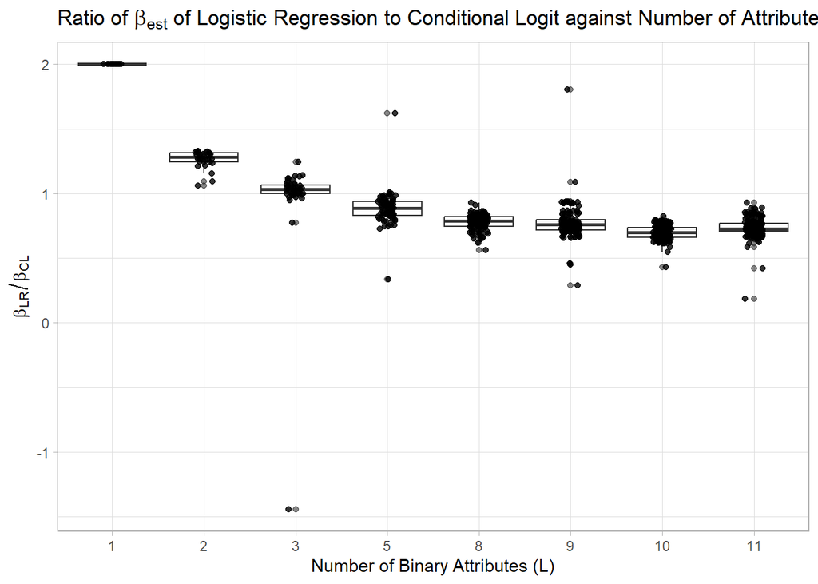

```r
# 計算每一組「獨立 true_beta」在兩個模型參數的比值 (LR / CL)
final_results_df %>%
  filter(Term != "Intercept") %>%
  # group_by(Scenario_L, Beta_Draw_ID) %>%
  # summarise(
  #   # 利用迴歸斜率算出該組特定 beta 的縮水比例
  #   # Robust_Shrink_Ratio = coef(lm(LR_Mean ~ 0 + CL_Mean))[1],
  #   ratio = LR_Mean / CL_Mean,
  #   .groups = "drop"
  # ) %>%
  # --- 繪製 Boxplot + Jitter (觀察特定 Beta 組合的影響) ---
  ggplot(aes(x = as.factor(Scenario_L), y = Ratio_LR_CL)) +
  # geom_violin() +

  # 加入箱型圖，顯示中位數與四分位距 (IQR)
  geom_boxplot(alpha = 0.6, position = position_dodge(width = 0.8)) +
  #
  # # 加入散佈點 (每一個點代表一組完全不同的 true_beta 組合)
  geom_jitter(
    position = position_jitterdodge(jitter.width = 0.3, dodge.width = 0.8),
    size = 1.5, alpha = 0.8
  ) +
  theme_light() +
  labs(
    title = TeX("Ratio of $\\beta_{est}$ of Logistic Regression to Conditional Logit against Number of Attributes"),
    x = "Number of Binary Attributes (L)",
    y = TeX("$\\beta_{LR} / \\beta_{CL}$")
  )
```

Each point indicates one $\beta$ value.

As we can see, when there is only 1 binary attribute, the ratio is 2. As the number of attributes increases, the ratio tends to decreases.

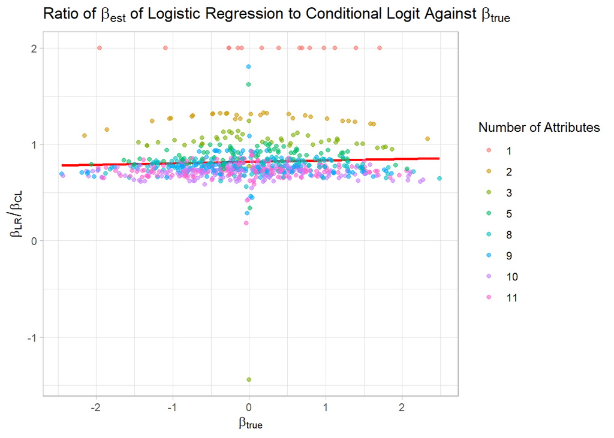

```r
final_results_df %>%
  filter(Term != "Intercept") %>%
  # group_by(Scenario_L, Beta_Draw_ID) %>%
  # summarise(
  #   # 利用迴歸斜率算出該組特定 beta 的縮水比例
  #   # Robust_Shrink_Ratio = coef(lm(LR_Mean ~ 0 + CL_Mean))[1],
  #   ratio = LR_Mean / CL_Mean,
  #   .groups = "drop"
  # ) %>%
  # --- 繪製 Boxplot + Jitter (觀察特定 Beta 組合的影響) ---
  ggplot(aes(x = True_Beta, y = Ratio_LR_CL, color= as.factor(Scenario_L))) +
  geom_smooth(method="lm", se=F, color="red", alpha=.6) +
  geom_point(alpha=0.6) +
  theme_light() +
  labs(
    title = TeX("Ratio of $\\beta_{est}$ of Logistic Regression to Conditional Logit Against $\\beta_{true}$"),
    x = TeX("$\\beta_{true}$"),
    y = TeX("$\\beta_{LR} / \\beta_{CL}$"),
    color = "Number of Attributes"
  )
```

The red line is the regression line of the ratio $\beta_{LR}\over\beta_{CL}$ against $\beta_{true}$, and the CI of the slope is $[-0.044, 0.022]$. Thus, there is no correlation between $\beta_{true}$ and the ratio $\beta_{LR}\over\beta_{CL}$.

#### 4.3.2. Intercept of Logistic Regression Against Number of Attributes

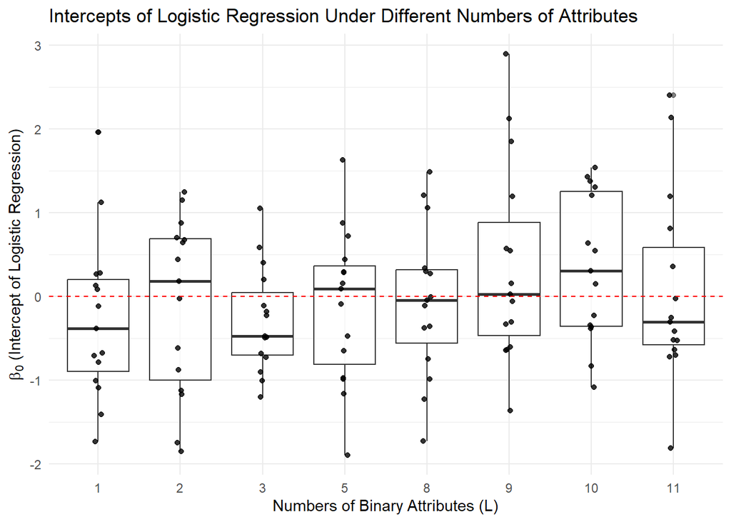

```r
final_results_df %>%
  filter(Term == "Intercept") %>%
  ggplot(aes(x = as.factor(Scenario_L), y = LR_Mean)) +
  geom_boxplot(alpha = 0.6, position = position_dodge(width = 0.8)) +
  # 加入散佈點 (每一個點代表一組完全不同的 true_beta 組合)
  geom_jitter(position = position_jitterdodge(jitter.width = 0.15, dodge.width = 0.8),
              size = 1.5, alpha = 0.8) +
  geom_hline(yintercept = 0, linetype = "dashed", color = "red") +
  # geom_smooth(aes(x=Scenario_L), method="lm", se=F) +
  theme_minimal() +
  labs(
    title = "Intercepts of Logistic Regression Under Different Numbers of Attributes",
    x = "Numbers of Binary Attributes (L)",
    y = TeX("$\\beta_0$ (Intercept of Logistic Regression)")
  )
```

It seems that the value of $\beta_0$ has nothing to do with the numbers of attributes ($L$).

#### 4.3.3. $\text{Bias}^2$ of Estimations

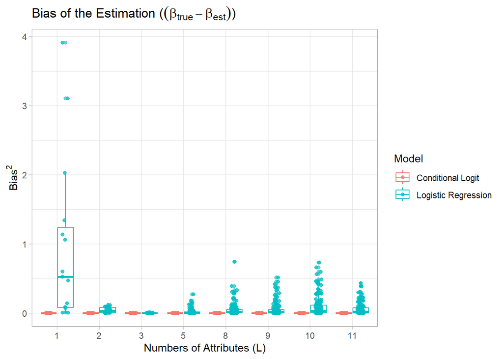

```r
final_results_df %>%
  filter(Term != "Intercept") %>%
  mutate(
    CL_Bias = CL_Bias ^ 2,
    LR_Bias = LR_Bias ^ 2
  ) %>%
  group_by(Scenario_L) %>%
  select(c(Term, True_Beta, CL_Bias, LR_Bias, Scenario_L, Beta_Draw_ID)) %>%
  pivot_longer(
    cols=ends_with("_Bias"),
    names_to = "Model", names_pattern = "(.*)_Bias",
    values_to = "Bias"
  ) %>%
  mutate(
    Model = recode(Model, CL="Conditional Logit", LR="Logistic Regression"),
    Model = as.factor(Model)
  ) %>%
  ggplot(aes(x=as.factor(Scenario_L), y=Bias, color=Model)) +
  geom_boxplot(alpha = 0.6, position = position_dodge(width = 0.8)) +
  geom_jitter(
    position = position_jitterdodge(jitter.width = 0.3, dodge.width = 0.8),
    size = 1.5, alpha = 0.8
  ) +
  labs(
    title = TeX("Bias of the Estimation ($(\\beta_{true} - \\beta_{est})^2$)"),
    x = "Numbers of Attributes (L)",
    y = TeX("${Bias}^2$")
  ) +
  theme_light()
```

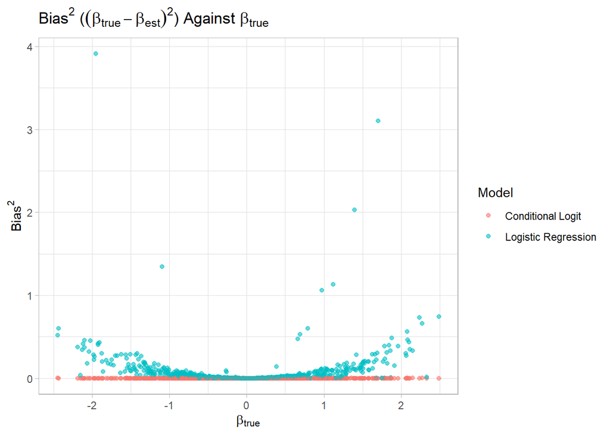

```r
final_results_df %>%
  filter(Term != "Intercept") %>%
  mutate(
    CL_Bias = CL_Bias ^ 2,
    LR_Bias = LR_Bias ^ 2
  ) %>%
  group_by(Scenario_L) %>%
  select(c(Term, True_Beta, CL_Bias, LR_Bias, Scenario_L, Beta_Draw_ID)) %>%
  pivot_longer(
    cols=ends_with("_Bias"),
    names_to = "Model", names_pattern = "(.*)_Bias",
    values_to = "Bias"
  ) %>%
  mutate(
    Model = recode(Model, CL="Conditional Logit", LR="Logistic Regression"),
    Model = as.factor(Model)
  ) %>%
  # lm(Bias ~ True_Beta*Scenario_L*Model, .) %>% summary()
  ggplot(aes(x=True_Beta, y=Bias, color=Model)) +
  # ggplot(aes(x=True_Beta, y=Bias, shape=Model, color=as.factor(Scenario_L))) +
  # geom_hline(yintercept=0, color="red") +
  geom_point(alpha=.6) +
  labs(
    title = TeX("${Bias}^2$ ($(\\beta_{true} - \\beta_{est})^2$) Against $\\beta_{true}$"),
    x = TeX("$\\beta_{true}$"),
    y = TeX("${Bias}^2$")
  ) +
  theme_light()
```

The squared bias of logistic regression grow as $\beta_{true}$ moves away from zero, while that of conditional logit remain unaffected.

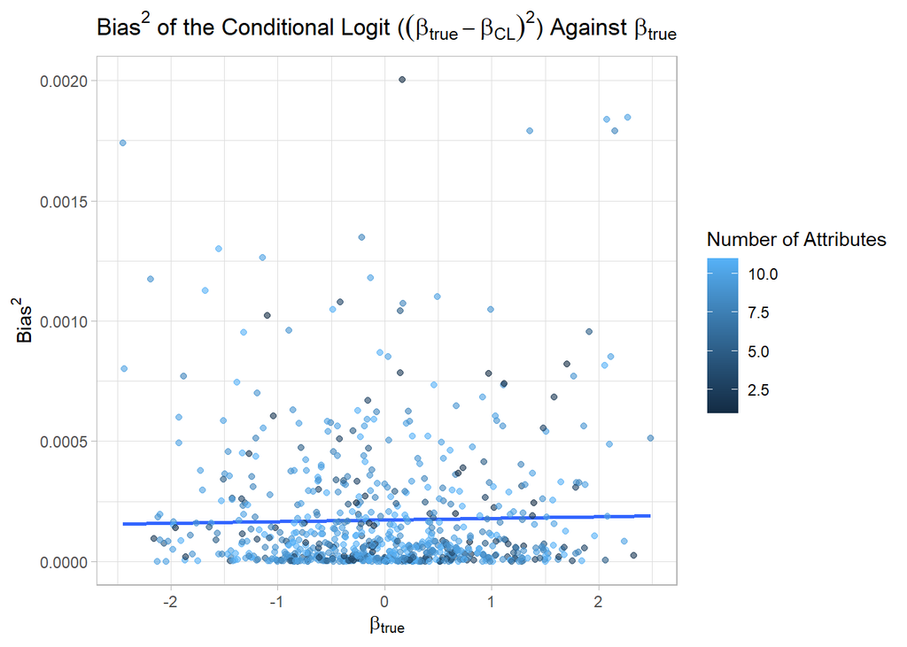

```r
final_results_df %>%
  filter(Term != "Intercept") %>%
  mutate(CL_Bias = CL_Bias ^ 2) %>%
  group_by(Scenario_L) %>%
  select(c(Term, True_Beta, CL_Bias, Scenario_L, Beta_Draw_ID)) %>%
  ggplot(aes(x=True_Beta, y=CL_Bias, color=Scenario_L)) +
  geom_smooth(method="lm", se=F) +
  # geom_hline(yintercept=0, color="red") +
  geom_point(alpha=.6) +
  labs(
    title = TeX("${Bias}^2$ of the Conditional Logit ($(\\beta_{true} - \\beta_{CL})^2$) Against $\\beta_{true}$"),
    x = TeX("$\\beta_{true}$"),
    y = TeX("${Bias}^2$"),
    color = "Number of Attributes"
  ) +
  theme_light()
```

Focusing on the squared bias of the conditional logit, there is no special patterns.

#### 4.3.4. Variation of Estimation

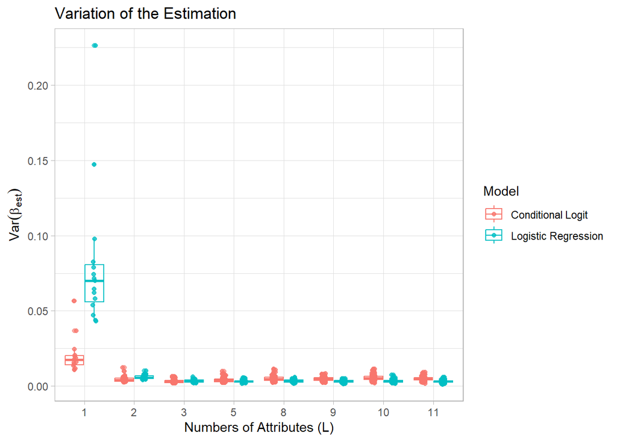

```r
final_results_df %>%
  filter(Term != "Intercept") %>%
  mutate(
    CL_Bias = CL_Bias ^ 2,
    LR_Bias = LR_Bias ^ 2
  ) %>%
  group_by(Scenario_L) %>%
  select(c(Term, CL_Var, LR_Var, Scenario_L, Beta_Draw_ID)) %>%
  pivot_longer(
    cols=ends_with("_Var"),
    names_to = "Model", names_pattern = "(.*)_Var",
    values_to = "Var"
  ) %>%
  mutate(
    Model = recode(Model, CL="Conditional Logit", LR="Logistic Regression"),
    Model = as.factor(Model)
  ) %>%
  ggplot(aes(x=as.factor(Scenario_L), y=Var, color=Model)) +
  geom_boxplot(alpha = 0.6, position = position_dodge(width = 0.8)) +
  # 加入散佈點 (每一個點代表一組完全不同的 true_beta 組合)
  geom_jitter(
    position = position_jitterdodge(jitter.width = 0.15, dodge.width = 0.8),
    size = 1.5, alpha = 0.8
  ) +
  labs(
    title = "Variation of the Estimation",
    x = "Numbers of Attributes (L)",
    y = TeX("$Var(\\beta_{est})$")
  ) +
  theme_light()
```

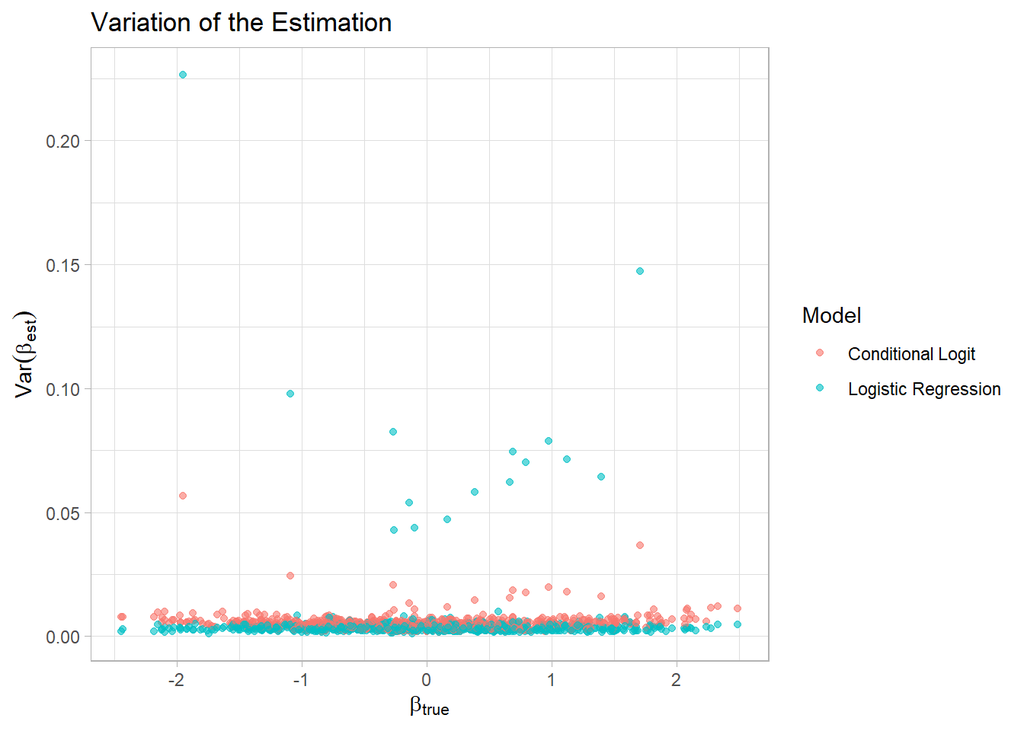

```r
final_results_df %>%
  filter(Term != "Intercept") %>%
  group_by(Scenario_L) %>%
  select(c(Term, True_Beta, CL_Var, LR_Var, Scenario_L, Beta_Draw_ID)) %>%
  pivot_longer(
    cols=ends_with("_Var"),
    names_to = "Model", names_pattern = "(.*)_Var",
    values_to = "Var"
  ) %>%
  mutate(
    Model = recode(Model, CL="Conditional Logit", LR="Logistic Regression"),
    Model = as.factor(Model)
  ) %>%
  ggplot(aes(x=True_Beta, y=Var, color=Model)) +
  geom_point(alpha=.6) +
  # geom_smooth(method=lm, formula = , se=F) +
  labs(
    title = "Variation of the Estimation",
    x = TeX("$\\beta_{true}$"),
    y = TeX("$Var(\\beta_{est})$")
  ) +
  theme_light()
```

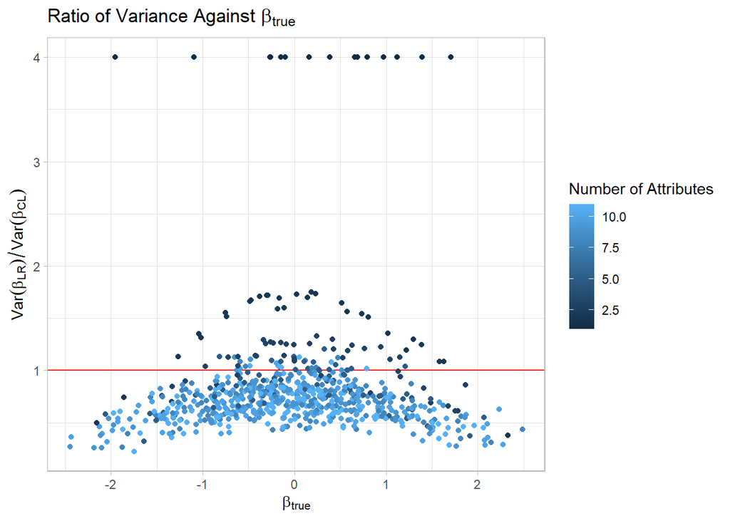

```r
final_results_df %>%
  filter(Term != "Intercept") %>%
  mutate(var_comp = LR_Var / CL_Var) %>%
  select(c(2, 12, 14)) %>%
  ggplot(aes(True_Beta, var_comp, color=Scenario_L)) +
  geom_hline(yintercept = 1, color="red") +
  geom_point() +
  theme_light() +
  labs(
    title = TeX("Ratio of Variance Against $\\beta_{true}$"),
    x = TeX("$\\beta_{true}$"),
    y = TeX("$Var(\\beta_{LR}) / Var(\\beta_{CL})$"),
    color = "Number of Attributes"
  )
```